% note to C. Paciorek: make of this is crashing in R 3.2.1 on smeagol but not R 3.2.0 on arwen

# By way of introduction…

- 3 main facilities for producing graphics in R: **base**, **lattice**, and **ggplot2**
  - In practice, these facilities are grouped into two camps: “basic” and “advanced”
- A better formulation: quick/dirty v. involved/fancy

# quick/dirty v. involved/fancy

- Recall that R is an object-oriented programming language

```r
tips <- reshape2::tips # Load dataset on tipping behavior included with reshape2 package
attributes(tips) # Check attributes of the tips dataset (names, row.names, class)
```

```
## $names
## [1] "total_bill" "tip"        "sex"        "smoker"     "day"
## [6] "time"       "size"
##
## $row.names
##   [1] "1"   "2"   "3"   "4"   "5"   "6"   "7"   "8"   "9"   "10"  "11"
##  [12] "12"  "13"  "14"  "15"  "16"  "17"  "18"  "19"  "20"  "21"  "22"
##  [23] "23"  "24"  "25"  "26"  "27"  "28"  "29"  "30"  "31"  "32"  "33"
##  [34] "34"  "35"  "36"  "37"  "38"  "39"  "40"  "41"  "42"  "43"  "44"
##  [45] "45"  "46"  "47"  "48"  "49"  "50"  "51"  "52"  "53"  "54"  "55"
##  [56] "56"  "57"  "58"  "59"  "60"  "61"  "62"  "63"  "64"  "65"  "66"
##  [67] "67"  "68"  "69"  "70"  "71"  "72"  "73"  "74"  "75"  "76"  "77"
##  [78] "78"  "79"  "80"  "81"  "82"  "83"  "84"  "85"  "86"  "87"  "88"
##  [89] "89"  "90"  "91"  "92"  "93"  "94"  "95"  "96"  "97"  "98"  "99"
## [100] "100" "101" "102" "103" "104" "105" "106" "107" "108" "109" "110"
```

[output cut: 16 more lines]

```r
# Create an object of class "lm" (linear model), regressing tip on some covariates
tips.reg <- lm(formula=tip~total_bill + sex + smoker + day + time + size, data=tips)
attributes(tips.reg) # Check attributes of the tips.reg object (names, class)
```

```
## $names
##  [1] "coefficients"  "residuals"     "effects"       "rank"
##  [5] "fitted.values" "assign"        "qr"            "df.residual"
##  [9] "contrasts"     "xlevels"       "call"          "terms"
## [13] "model"
##
## $class
## [1] "lm"
```

- Base graphics often recognizes the object type and will implement specific plot methods

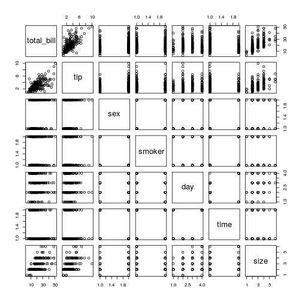

```r
plot(tips) # Calls plotting method for class of tips dataset ("data.frame")
```

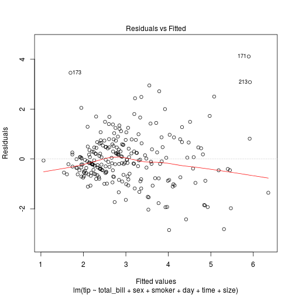

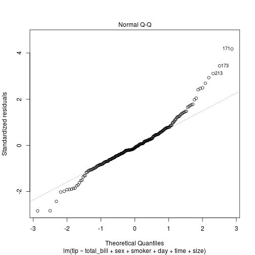

```r
plot(tips.reg, which=1:2) # Calls plotting method for class of tips.reg objects ("lm"), print first two plots only
```

- lattice and ggplot2 generally **don't** exhibit this sort of behavior

```r
xyplot(tips) # Attempt in lattice to automatically plot objects of class "data.frame"
```

```
## Error in UseMethod("xyplot"): no applicable method for 'xyplot' applied to an object of class "data.frame"
```

```r
ggplot(data=tips) + geom_point() # Attempt in ggplot to automatically plot objects of class "data.frame"
```

```
## Error in exists(name, envir = env, mode = mode): argument "env" is missing, with no default
```

```r
xyplot(tips.reg) # Attempt in lattice to automatically plot objects of class "lm"
```

```
## Error in UseMethod("xyplot"): no applicable method for 'xyplot' applied to an object of class "lm"
```

```r
ggplot(data=tips.reg) + geom_point() # Attempt in ggplot to automatically plot objects of class "lm"
```

```
## Error in exists(name, envir = env, mode = mode): argument "env" is missing, with no default
```

- Easiest to cover **lattice** and **ggplot2** in tandem

# The Dataset

For more info: http://www.ipw.unibe.ch/content/team/klaus_armingeon/comparative_political_data_sets/index_eng.html

# lattice v. ggplot2

- lattice is

a) faster (though only noticeable over many and large plots)

b) simpler (at first)

c) better at trellis graphs

d) able to do 3d graphs

- ggplot2 is

a) generally more elegant

b) more syntactically logical (and therefore simpler, once you learn it)

c) better at grouping

d) able to interface with maps

# Basic usage: lattice

The general call for lattice graphics looks something like this:

```r
graph_type(formula, data=, [options])
```

The specifics of the **formula** differ for each graph type, but the general format is straightforward

```r
y             # Show the distribution of y

y~x           # Show the relationship between x and y

y~x|A         # Show the relationship between x and y conditional on the values of A

y~x|A*B       # Show the relationship between x and y conditional on the combinations of A and B

z~y*x         # Show the 3D relationship between x, y, and z
```

# Basic usage: ggplot2

The general call for ggplot2 graphics looks something like this:

```r
ggplot(data=, aes(x=,y=, [options])) + geom_xxxx() + ... + ... + ...
```

Note that ggplot2 graphs in layers in a *continuing call* (hence the endless +…+…+…), which really makes the extra layer part of the call

```r
...+geom_xxxx(data=, aes(x=,y=,[options]),[options])+...+...+...
```

You can see the layering effect by comparing the same graph with different colors for each layer

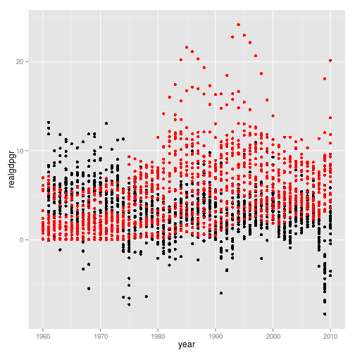

```r
ggplot(data=data, aes(x=year, y=realgdpgr)) + geom_point(color="black") + geom_point(aes(x=year, y=unemp), color="red")
```

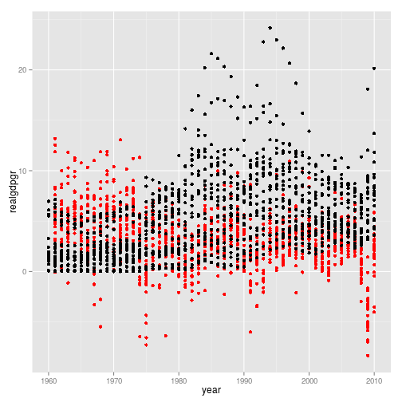

```r
ggplot(data=data, aes(x=year, y=realgdpgr)) + geom_point(color="red") + geom_point(aes(x=year, y=unemp), color="black")
```

# Comparing lattice and ggplot

- Density Plots
- Scatter Plots
- Line Plots
- Bar plots
- Box plots
- Trellis Plots
- Contour Plots
- Tile/Image Plots
- 3D Plots (lattice)
- Panel Plots (ggplot2)

# lattice v. ggplot2: Densities

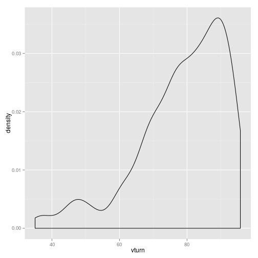

```r
ggplot(data=data, aes(x=vturn)) + geom_density() # ggplot2
```

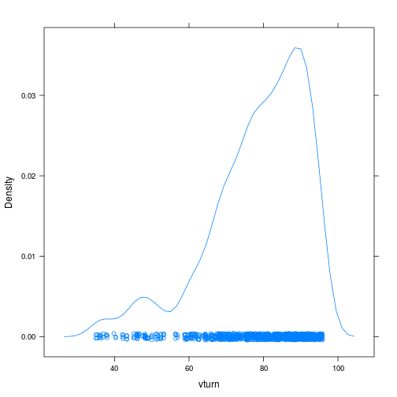

```r
densityplot(~vturn, data=data) # lattice
```

# lattice v. ggplot2: X-Y scatter plots

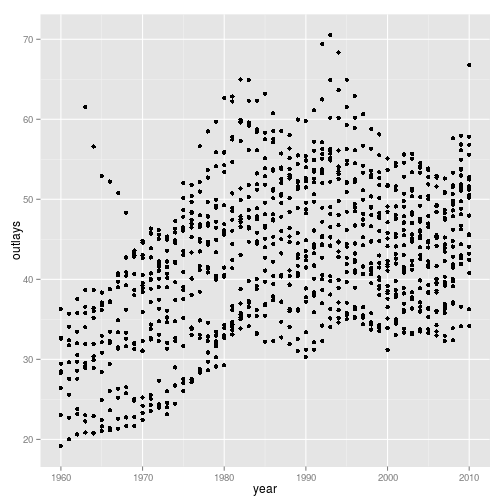

```r
ggplot(data=data, aes(x=year, y=outlays)) + geom_point() # ggplot2
```

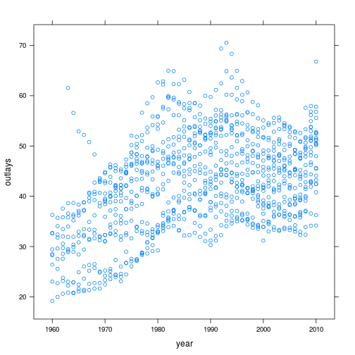

```r
xyplot(outlays~year, data=data) # lattice
```

# lattice v. ggplot2: X-Y line plots

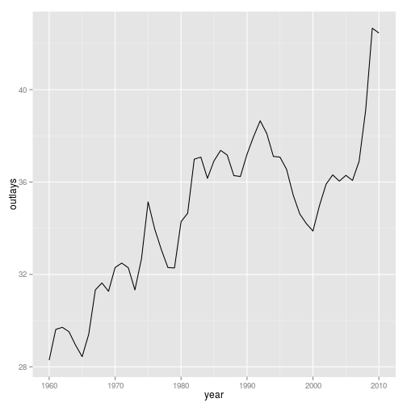

```r
ggplot(data=data[data$country=="USA",], aes(x=year, y=outlays)) + geom_line() # ggplot2
```

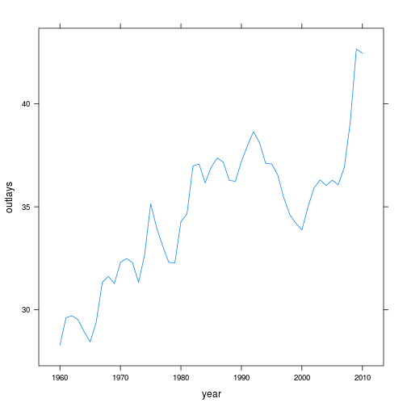

```r
xyplot(outlays~year, data=data[data$country=="USA",], type="l") # lattice
```

# lattice v. ggplot2: bar plots

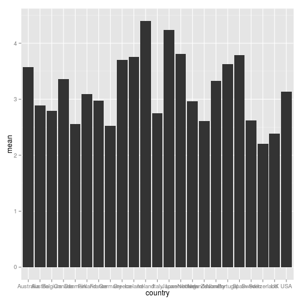

```r
# Create data.frame of average growth rates by country over time
growth <- ddply(.data=data, .variables=.(country), summarize, mean=mean(realgdpgr, na.rm=T))

ggplot(data=growth, aes(x=country, y=mean)) + geom_bar(stat="identity") # ggplot2
```

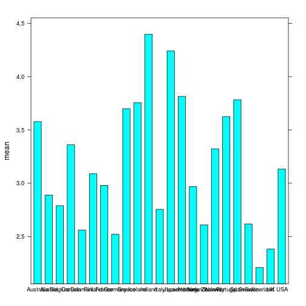

```r
barchart(mean~country, data=growth) # lattice
```

# lattice v. ggplot2: box plots

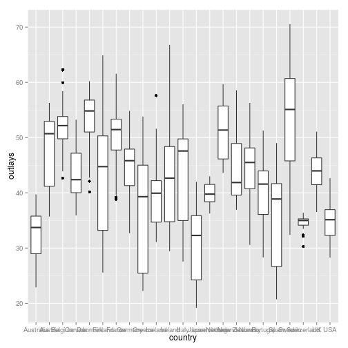

```r
ggplot(data=data, aes(x=country, y=outlays)) + geom_boxplot() # ggplot2
```

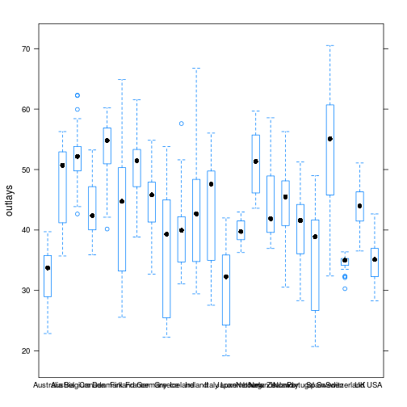

```r
bwplot(outlays~country, data=data) # lattice
```

# lattice v. ggplot2: “trellis” plots

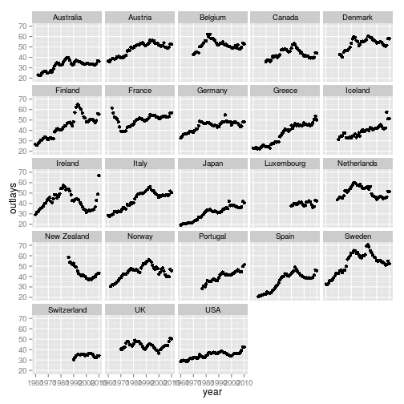

```r
ggplot(data=data, aes(x=year, y=outlays)) + geom_point() + facet_wrap(~country) # ggplot2
```

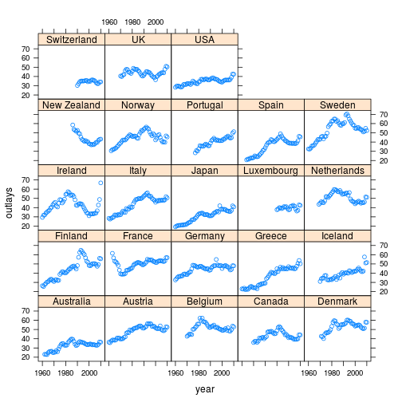

```r
xyplot(outlays~year|country, data=data) # lattice
```

# lattice v. ggplot2: countour plots

```r
data(volcano) # Load volcano contour data
volcano[1:10, 1:10] # Examine volcano dataset (first 10 rows and columns)
```

```
##       [,1] [,2] [,3] [,4] [,5] [,6] [,7] [,8] [,9] [,10]
##  [1,]  100  100  101  101  101  101  101  100  100   100
##  [2,]  101  101  102  102  102  102  102  101  101   101
##  [3,]  102  102  103  103  103  103  103  102  102   102
##  [4,]  103  103  104  104  104  104  104  103  103   103
##  [5,]  104  104  105  105  105  105  105  104  104   103
##  [6,]  105  105  105  106  106  106  106  105  105   104
##  [7,]  105  106  106  107  107  107  107  106  106   105
##  [8,]  106  107  107  108  108  108  108  107  107   106
##  [9,]  107  108  108  109  109  109  109  108  108   107
## [10,]  108  109  109  110  110  110  110  109  109   108
```

```r
volcano3d <- melt(volcano) # Use reshape2 package to melt the data
head(volcano3d) # Examine volcano3d dataset (head)
```

```
##   Var1 Var2 value
## 1    1    1   100
## 2    2    1   101
## 3    3    1   102
## 4    4    1   103
## 5    5    1   104
## 6    6    1   105
```

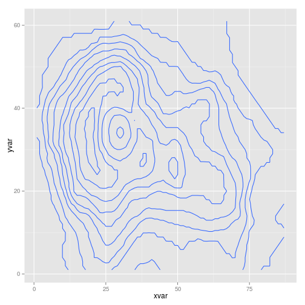

```r
names(volcano3d) <- c("xvar", "yvar", "zvar") # Rename volcano3d columns

ggplot(data=volcano3d, aes(x=xvar, y=yvar, z = zvar)) + geom_contour() # ggplot2
```

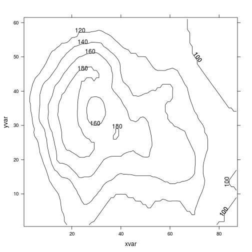

```r
contourplot(zvar~xvar + yvar, data=volcano3d) # lattice
```

# lattice v. ggplot2: tile/image/level plots

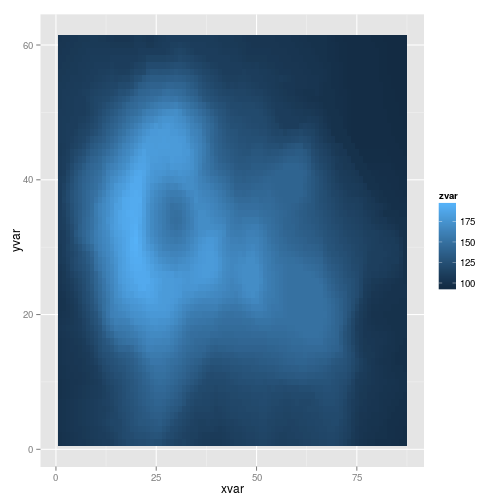

```r
ggplot(data=volcano3d, aes(x=xvar, y=yvar, z = zvar)) + geom_tile(aes(fill=zvar)) # ggplot2
```

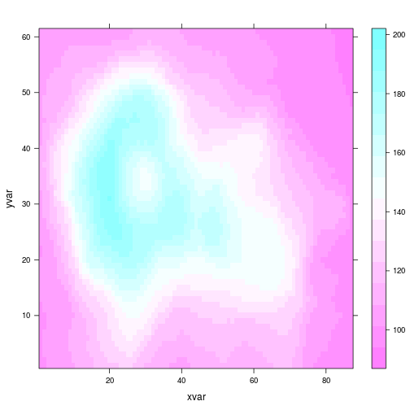

```r
levelplot(zvar~xvar + yvar, data=volcano3d) # lattice
```